# Praca domowa nr 3

Jakub Grzywaczewski

2022-11-22

## Wstęp

Przedstawiam poniżej efekty mojej pracy nad zbadaniem “czy wypracowane wzorce tworzenia dobrych wykresów dalej aplikują w dzisiejszych czasach” co było zadaniem Pracy Domowej nr 3. Jako obiekt badawczy wybrałem kolory, a dokładniej jak dobre dobranie kolorów jest istotne w poprawieniu czytelności wykresów.

Aspekt czytelności podzieliłem na dwie części:

1. Odróżnianie elementów oznaczonych kolorami
2. Czytelność tekstu na kolorowym tle

W pierwszej sekcji osoby ankietowane otrzymały dwa wykresy słupkowe z potrójnymi słupkami, które były oznaczone kolorami. Na pierwszych z nich użyłem odróżnialnych się od siebie kolorów do podpisania miast, natomiast w drugim użyłem bardzo zbliżonych do siebie odcieni ciemnej czerwieni. Celem tej części było sprawdzenie czy posiadanie oddzielnych informacji reprezentowanych przez dalekie sobie kolory jest lepsze, niż używanie kolorów bliskich sobie.

W drugiej sekcji sprawdzone było jak czytelny jest tekst na kolorowym tle. Ankietowana osoba miała przed sobą 3 wykresy słupkowe wszystkie z białym tłem. Na pierwszym wykresie kolor tekstu był jaskrawy i bliski kolorowi słupka, drugi wykres posiadał biały tekst na jasnobłękitnym słupku oraz trzeci wykres biały tekst na bordowym słupku.

## Dane

Ze względu na uproszczenie, skupiłem się dokładniej na latach 2012-2022 oraz na rynku wtórnym dla tych 16 miast.

Link do [pliku](https://www.nbp.pl/publikacje/rynek_nieruchomosci/ceny_mieszkan.xlsx) xlsx z danymi.

## Ankieta i wyniki

Ankieta została rozesłana do różnych osób z poza branży. Otrzymałem 19 odpowiedzi.

### Odróżnianie elementów oznaczonych kolorami

#### Pytania

Dwa wykresy z tym samym pytaniem:

“W skali od 1 do 5 oceń jak długo zajęło Ci odczytanie wykresu” Gdzie 1 na skali oznacza “Natychmiast”, a 5 oznacza “Dłuższą chwilę”

**Wykres1: “Odróżniające kolory”**

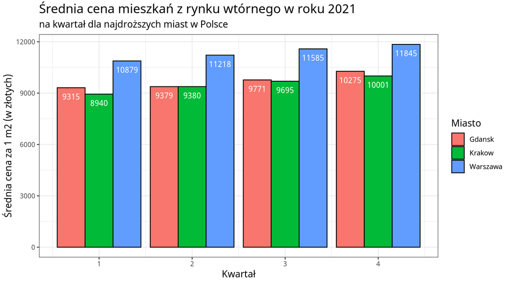

**Wykres2: “Odcienie czerwonego”**

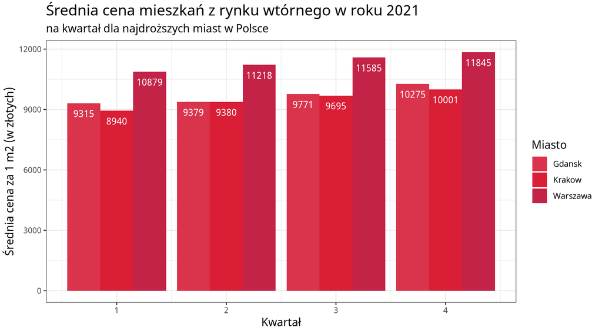

Dodatkowym pytaniem do tych wykresów było: “Na którym wykresie było to łatwiejsze? Którego rodzaju wykresu wolałbyś zobaczyć?” Opcjami były:

1. Wykres nr 1
2. Wykres nr 2

#### Wyniki

Odnośnie czasu odczytania **wykresu nr 1** rozkład głosów prezentuje się następująco:

| Ocena | Głosy |
| --- | --- |
| 1 - Natychmiast | 1 |
| 2 | 12 |
| 3 | 5 |
| 4 | 0 |
| 5 - Dłuższą chwilę | 1 |

Natomiast w przypadku **wykresu nr 2** mamy praktycznie odwrotną sytuację

[output not shown]

Na pytanie o wybraniu jednego z owych dwóch wykresów większość wybrała wykres nr 1 z odróżniającymi się kolorami (18 osób - 94,7%), pozostałą 1 osoba wybrała wykres numer 2 z odcieniami czerwonego.

### Czytelność kolorowego tekstu na kolorowym tle

#### Pytania

Następujące pytanie było zadane do każdego z trzech wykresów:

“Oceń w skali od 1 do 5 czytelność wykresu.” , gdzie 1 była oznaczona “Nic nie widać”, a 5 “Czytelny”.

**Wykres1: “Jaskrawe kolory”**

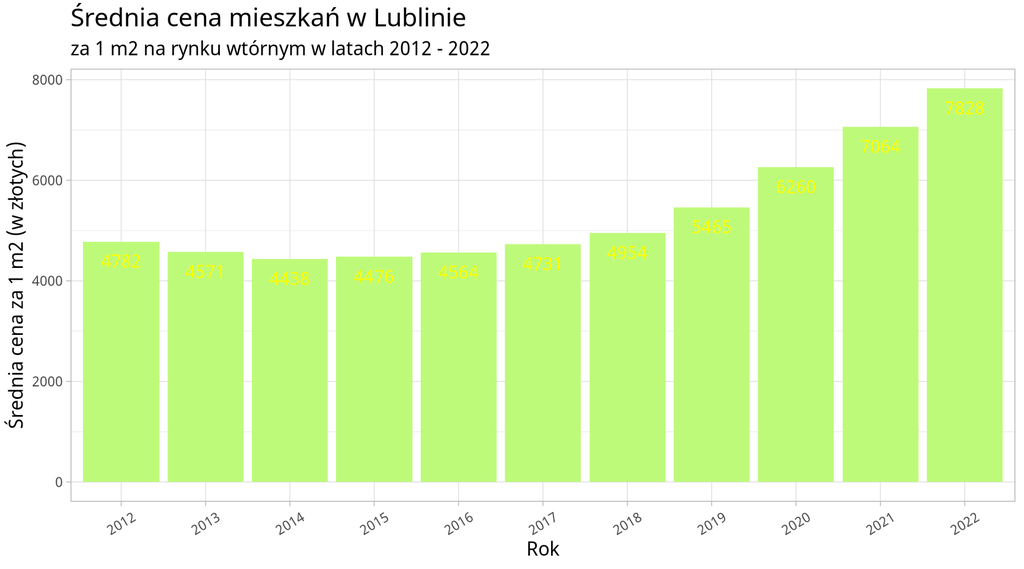

**Wykres2: “Jasnoniebieskie tło”**

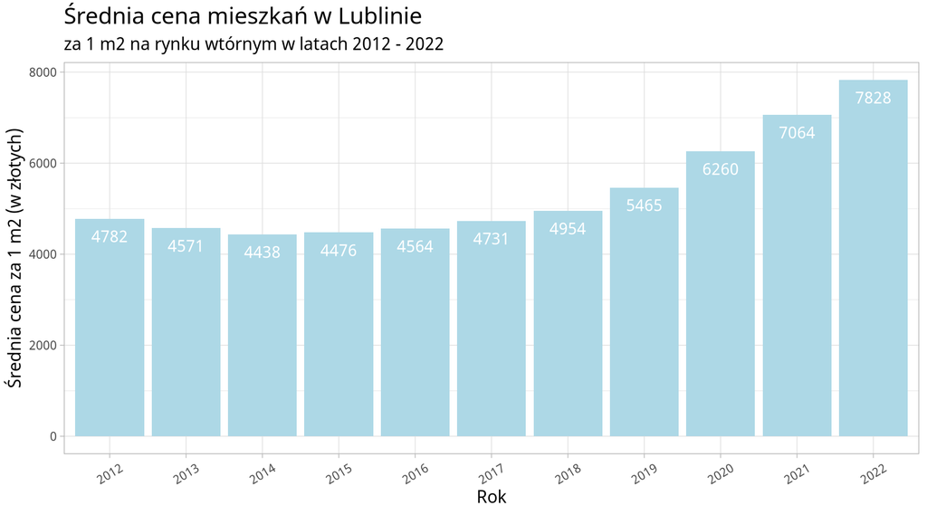

**Wykres3: “Ciemnoczerwone tło”**

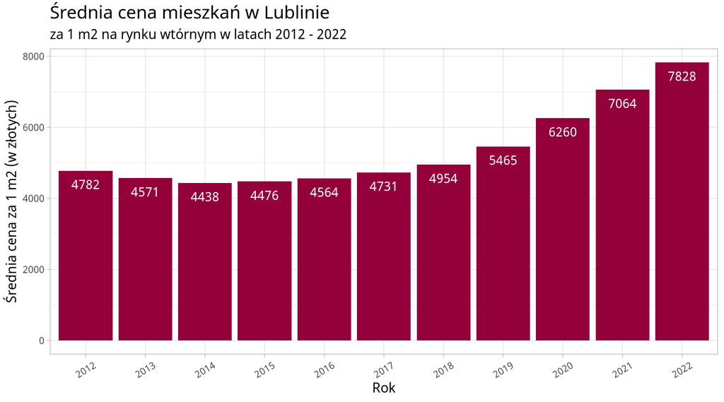

Odnośnie czytelności **wykresu nr 1** rozkład głosów prezentuje się następująco:

| Ocena | Głosy |
| --- | --- |
| 1 - Nic nie widać | 2 |
| 2 | 9 |
| 3 | 7 |
| 4 | 0 |
| 5 - Czytelny | 1 |

**Wykres nr 2** prezentuje się natomiast lepiej z wynikami:

| Ocena | Głosy |
| --- | --- |
| 1 - Nic nie widać | 0 |
| 2 | 1 |
| 3 | 3 |
| 4 | 9 |
| 5 - Czytelny | 6 |

Lecz mimo to, z najlepszymi ocenami pod względem czytelności wychodzi **wykres nr 3**:

| Ocena | Głosy |
| --- | --- |
| 1 - Nic nie widać | 0 |
| 2 | 1 |
| 3 | 0 |
| 4 | 2 |
| 5 - Czytelny | 16 |

## Wnioski

Oczywistym wnioskiem z przedstawionych wyników jest fakt, iż kolory na wykresach mają znaczenie. W przypadku kiedy oznaczamy kolorami odróżnialne elementy wykresu lepiej prezentują się barwy, które są daleko od siebie i nie wymęczają oczu oglądającego. Ankietowani niemalże jednogłośnie wybrali wykres z kolorami dobranymi w taki sposób, aby ich odróżnienie nie wymagało dodatkowej pracy. Podczas odczytywania wykresu interesują nas dane i wiadomość jaką niesie owy wykres, nie chcemy tracić czasu zastanawiając się jaki to jest odcień czerwonego. Problem odróżnienia barw byłby jeszcze bardziej wyraźny u osób z daltonizmem, dla których owe odcienie czerwonego mogłyby stać się fizycznie nierozróżnialne. Natomiast w przypadku doboru kolorów tekstu i otaczającego tekst tła ankietowani preferowali tekst, który widocznie kontrastował z kolorem słupka. Ten aspekt był najważniejszy, lecz z wyników ankiet dodatkowym wnioskiem jest, iż sam słupek nie powinien być za blisko koloru tła całego wykresu, aby uniknąć problemów z czytelnością.

Podsumowując użycie odpowiednich kolorów i dbanie o harmoniczne rozłożenie tych kolorów na wykresie zapewni nam czytelność tekstu oraz ułatwi nam przekaz informacji. Co wspiera wypracowane standardy tworzenia wykresów.